# Deliverable 3-Copy1

```python
import numpy as np
import pandas as pd
import matplotlib.pyplot as plt
```

```python
# load dataset designating AVG to be index
hitting_stats = pd.read_csv("baseball_hitting.csv", index_col = "AVG")

# print first 10 rows
hitting_stats.head()
```

| AVG | Player name | position | Games | At-bat | Runs | Hits | Double (2B) | third baseman | home run | run batted in | a walk | Strikeouts | stolen base | Caught stealing | On-base Percentage | Slugging Percentage | On-base Plus Slugging |
| --- | --- | --- | --- | --- | --- | --- | --- | --- | --- | --- | --- | --- | --- | --- | --- | --- | --- |
| 0.298 | B Bonds | LF | 2986.0 | 9847.0 | 2227.0 | 2935.0 | 601.0 | 77.0 | 762.0 | 1996.0 | 2558.0 | 1539 | 514.0 | 141 | 0.444 | 0.607 | 1.051 |
| 0.305 | H Aaron | RF | 3298.0 | 12364.0 | 2174.0 | 3771.0 | 624.0 | 98.0 | 755.0 | 2297.0 | 1402.0 | 1383 | 240.0 | 73 | 0.374 | 0.555 | 0.929 |
| 0.342 | B Ruth | RF | 2504.0 | 8399.0 | 2174.0 | 2873.0 | 506.0 | 136.0 | 714.0 | 2213.0 | 2062.0 | 1330 | 123.0 | 117 | 0.474 | 0.690 | 1.164 |
| 0.296 | A Pujols | 1B | 3080.0 | 11421.0 | 1914.0 | 3384.0 | 686.0 | 16.0 | 703.0 | 2218.0 | 1373.0 | 1404 | 117.0 | 43 | 0.374 | 0.544 | 0.918 |
| 0.295 | A Rodriguez | SS | 2784.0 | 10566.0 | 2021.0 | 3115.0 | 548.0 | 31.0 | 696.0 | 2086.0 | 1338.0 | 2287 | 329.0 | 76 | 0.380 | 0.550 | 0.930 |

```python
print(repr(hitting_stats.columns))
hitting_stats.rename(columns=lambda x: x.strip(), inplace=True)
```

```
Index(['Player name', 'position', 'Games', 'At-bat', 'Runs', 'Hits',
       'Double (2B)', 'third baseman', 'home run', 'run batted in', 'a walk',
       'Strikeouts', 'stolen base ', 'Caught stealing', 'On-base Percentage',
       'Slugging Percentage', 'On-base Plus Slugging'],
      dtype='object')
```

```python
hitting_stats.columns = hitting_stats.columns.str.strip()
hitting_stats.rename(columns={
    "position": "Position",
    "Games": "Games Played",
    "At-bat": "At-Bats",
    "Runs": "Runs",
    "Double (2B)": "Double (2B)",
    "third baseman": "Third Baseman",
    "home run": "Home Run",
    "run batted in": "Run Batted In",
    "a walk": "Walks",
    "Strikeouts": "Strikeouts",
    "stolen base": "Stolen Base",
    "Caught stealing": "Caught Stealing",
    "Slugging Percentage": "Slugging Percentage",
    "On-base Plus Slugging": "On-base Plus Slugging"
}, inplace=True)

print(hitting_stats.columns)
```

```
Index(['Player name', 'Position', 'Games Played', 'At-Bats', 'Runs', 'Hits',
       'Double (2B)', 'Third Baseman', 'Home Run', 'Run Batted In', 'Walks',
       'Strikeouts', 'Stolen Base', 'Caught Stealing', 'On-base Percentage',
       'Slugging Percentage', 'On-base Plus Slugging'],
      dtype='object')
```

```python
hitting_stats
```

| AVG | Player name | Position | Games Played | At-Bats | Runs | Hits | Double (2B) | Third Baseman | Home Run | Run Batted In | Walks | Strikeouts | Stolen Base | Caught Stealing | On-base Percentage | Slugging Percentage | On-base Plus Slugging |
| --- | --- | --- | --- | --- | --- | --- | --- | --- | --- | --- | --- | --- | --- | --- | --- | --- | --- |
| 0.298 | B Bonds | LF | 2986.0 | 9847.0 | 2227.0 | 2935.0 | 601.0 | 77.0 | 762.0 | 1996.0 | 2558.0 | 1539 | 514.0 | 141 | 0.444 | 0.607 | 1.051 |
| 0.305 | H Aaron | RF | 3298.0 | 12364.0 | 2174.0 | 3771.0 | 624.0 | 98.0 | 755.0 | 2297.0 | 1402.0 | 1383 | 240.0 | 73 | 0.374 | 0.555 | 0.929 |
| 0.342 | B Ruth | RF | 2504.0 | 8399.0 | 2174.0 | 2873.0 | 506.0 | 136.0 | 714.0 | 2213.0 | 2062.0 | 1330 | 123.0 | 117 | 0.474 | 0.690 | 1.164 |
| 0.296 | A Pujols | 1B | 3080.0 | 11421.0 | 1914.0 | 3384.0 | 686.0 | 16.0 | 703.0 | 2218.0 | 1373.0 | 1404 | 117.0 | 43 | 0.374 | 0.544 | 0.918 |
| 0.295 | A Rodriguez | SS | 2784.0 | 10566.0 | 2021.0 | 3115.0 | 548.0 | 31.0 | 696.0 | 2086.0 | 1338.0 | 2287 | 329.0 | 76 | 0.380 | 0.550 | 0.930 |
| ... | ... | ... | ... | ... | ... | ... | ... | ... | ... | ... | ... | ... | ... | ... | ... | ... | ... |
| 0.224 | R Derry | LF | 187.0 | 553.0 | 68.0 | 124.0 | 17.0 | 7.0 | 17.0 | 73.0 | 78.0 | 124 | 2.0 | 0 | 0.322 | 0.373 | 0.695 |
| 0.219 | M Kittridge | C | 470.0 | 4027.0 | 375.0 | 882.0 | 108.0 | 31.0 | 17.0 | 390.0 | 314.0 | 166 | 64.0 | -- | 0.277 | 0.274 | 0.551 |
| 0.303 | G DeMontreville | 2B | 280.0 | 3615.0 | 537.0 | 1096.0 | 130.0 | 35.0 | 17.0 | 497.0 | 174.0 | 35 | 228.0 | -- | 0.340 | 0.373 | 0.713 |
| 0.246 | L Niekro | 1B | 195.0 | 499.0 | 61.0 | 123.0 | 26.0 | 5.0 | 17.0 | 79.0 | 29.0 | 91 | 0.0 | 2 | 0.288 | 0.421 | 0.709 |
| 0.266 | B Whitehead | 2B | 924.0 | 3316.0 | 415.0 | 883.0 | 100.0 | 31.0 | 17.0 | 245.0 | 150.0 | 138 | 51.0 | -- | 0.304 | 0.331 | 0.635 |

2508 rows × 17 columns

```
AVG
0.367         T Cobb
0.358      R Hornsby
0.356      J Jackson
0.349       L O'Doul
0.346    E Delahanty
0.345      T Speaker
0.344     B Hamilton
0.344     T Williams
0.344     B Hamilton
0.342     H Heilmann
0.342    D Brouthers
0.342         B Ruth
0.341     P Browning
0.341       W Keeler
0.341        B Terry
Name: Player name, dtype: object
```

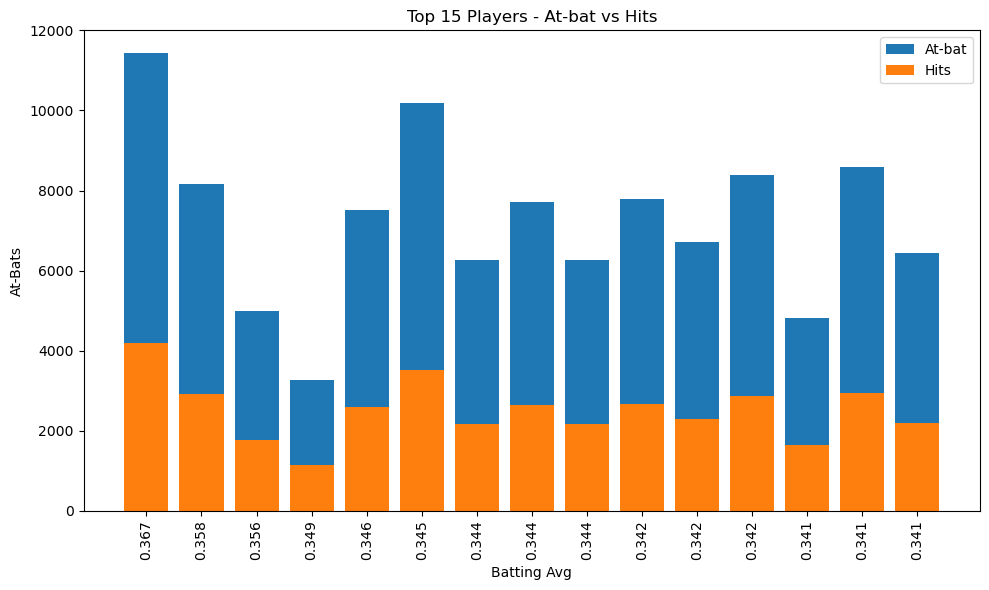

```python
import pandas as pd
import matplotlib.pyplot as plt

# Load the dataset and set "AVG" as the index column
hitting_stats = pd.read_csv("baseball_hitting.csv", index_col="AVG")

# Sort the dataset by "AVG" in descending order
sorted_stats = hitting_stats.sort_values(by="AVG", ascending=False)

# Select the top 15 rows
top_15 = sorted_stats.head(15)

# Print the names of the players
print(top_15["Player name"])

# Create a bar chart with player names and their At-bat vs Hits
plt.figure(figsize=(10, 6))
plt.bar(range(len(top_15)), top_15["At-bat"], label="At-bat")
plt.bar(range(len(top_15)), top_15["Hits"], label="Hits")

# Set the x-axis ticks and labels
plt.xticks(range(len(top_15)), top_15.index, rotation='vertical')

# Set the chart title and axis labels
plt.title("Top 15 Players - At-bat vs Hits")
plt.xlabel("Batting Avg")
plt.ylabel("At-Bats")

# Add legend and adjust layout
plt.legend()
plt.tight_layout()

# Display the chart
plt.show()
```

We chose a bar graph to compare the At-Bats vs Hits for the top 15 players with the highest batting averages because it helps analyze the at-bats, hits, and averages for each player. The visualizations it gives makes reading the data easy to follow and understand. Along with readability, the bar graph lets us effectivly compare players directly with each other or against themselves and their personal stats. This combination emphasizes the players differences in batting averages despite having varying plate apperances. Additionally, the bar graph is clear with its overview which gave us a chance to ID the players with the highest batting averages and their personal hitting stats.

```python
import pandas as pd

def read_pitcher_stats(file_name):
    pitcher_stats = pd.read_csv(file_name, index_col=0)
    return pitcher_stats

# Usage example
pitcher_stats = read_pitcher_stats("baseball_pitcher.csv")
print(pitcher_stats)
```

```
                Position    Win   Loss  Earned run Average  Games played  \
Player name
N Ryan                 P  324.0  292.0                3.19         807.0
R Johnson              P  303.0  166.0                3.29         618.0
R Clemens              P  354.0  184.0                3.12         709.0
S Carlton              P  329.0  244.0                3.22         741.0
B Blyleven             P  287.0  250.0                3.31         692.0
...                  ...    ...    ...                 ...           ...
E Bell                 P   15.0   18.0                5.18          68.0
D Ponce de Leon        P    3.0    8.0                4.33          57.0
A Decatur              P   23.0   34.0                4.51         153.0
L Sleater              P   12.0   18.0                4.70         131.0
R Hinton               P    9.0   17.0                4.87         116.0

                 Games Started  Complete Game  Shutout  Save Save Opportunity  \
Player name
N Ryan                   773.0          222.0     61.0   3.0                4
R Johnson                603.0          100.0     37.0   2.0                3
R Clemens                707.0          118.0     46.0   0.0                0
S Carlton                709.0          254.0     55.0   2.0                2
B Blyleven               685.0          242.0     60.0   0.0                0
...                        ...            ...      ...   ...              ...
E Bell                    34.0            2.0      0.0   0.0                0
D Ponce de Leon           22.0            0.0      0.0   3.0                4
A Decatur                 37.0           10.0      0.0   7.0               --
L Sleater                 21.0            7.0      1.0   5.0               --
R Hinton                  13.0            2.0      0.0   3.0                5

                 Innings pitched     hit     run  earned run  home run  \
Player name
N Ryan                    5386.0  3923.0  2178.0      1911.0     321.0
R Johnson                 4135.1  3346.0  1703.0      1513.0     411.0
R Clemens                 4916.2  4185.0  1885.0      1707.0     363.0
S Carlton                 5217.1  4672.0  2130.0      1864.0     414.0
B Blyleven                4970.0  4632.0  2029.0      1830.0     430.0
...                          ...     ...     ...         ...       ...
E Bell                     234.2   238.0   150.0       135.0      38.0
D Ponce de Leon            147.2   115.0    73.0        71.0      21.0
A Decatur                  538.1   653.0   319.0       270.0      42.0
L Sleater                  300.2   306.0   181.0       157.0      32.0
R Hinton                   249.2   283.0   152.0       135.0      23.0

                  Hit Batsmen  base on balls  Strikeouts  WHIP    AVG
Player name
N Ryan                  158.0         2795.0      5714.0  1.25  0.204
R Johnson               190.0         1497.0      4875.0  1.17  0.221
R Clemens               159.0         1580.0      4672.0  1.17  0.229
S Carlton                53.0         1833.0      4136.0  1.25   0.24
B Blyleven              155.0         1322.0      3701.0  1.20  0.248
...                       ...            ...         ...   ...    ...
E Bell                    4.0          112.0       152.0  1.49  0.264
D Ponce de Leon          10.0           81.0       152.0  1.33  0.213
A Decatur                13.0          145.0       152.0  1.48  0.302
L Sleater                 8.0          172.0       152.0  1.59  0.263
R Hinton                  7.0           91.0       152.0  1.50  0.289

[2577 rows x 20 columns]
```

```python
import pandas as pd

def load_pitcher_stats():
    pitcher_stats = pd.read_csv("baseball_pitcher.csv", index_col="AVG")
    return pitcher_stats

# Usage example
pitcher_stats = load_pitcher_stats()

# Print first 10 rows
print(pitcher_stats.head(10))
```

```
      Player name Position    Win   Loss  Earned run Average  Games played  \
AVG
0.204      N Ryan        P  324.0  292.0                3.19         807.0
0.221   R Johnson        P  303.0  166.0                3.29         618.0
0.229   R Clemens        P  354.0  184.0                3.12         709.0
0.24    S Carlton        P  329.0  244.0                3.22         741.0
0.248  B Blyleven        P  287.0  250.0                3.31         692.0
0.226    T Seaver        P  311.0  205.0                2.86         656.0
0.236    D Sutton        P  324.0  256.0                3.26         774.0
0.245     G Perry        P  314.0  265.0                3.11         777.0
0.227   W Johnson        P  417.0  279.0                2.17         802.0
0.25     G Maddux        P  355.0  227.0                3.16         744.0

       Games Started  Complete Game  Shutout  Save Save Opportunity  \
AVG
0.204          773.0          222.0     61.0   3.0                4
0.221          603.0          100.0     37.0   2.0                3
0.229          707.0          118.0     46.0   0.0                0
0.24           709.0          254.0     55.0   2.0                2
0.248          685.0          242.0     60.0   0.0                0
0.226          647.0          231.0     61.0   1.0                2
0.236          756.0          178.0     58.0   5.0                5
0.245          690.0          303.0     53.0  11.0               12
0.227          666.0          531.0    110.0  34.0               --
0.25           740.0          109.0     35.0   0.0                0

       Innings pitched     hit     run  earned run  home run   Hit Batsmen  \
AVG
0.204           5386.0  3923.0  2178.0      1911.0     321.0         158.0
0.221           4135.1  3346.0  1703.0      1513.0     411.0         190.0
0.229           4916.2  4185.0  1885.0      1707.0     363.0         159.0
0.24            5217.1  4672.0  2130.0      1864.0     414.0          53.0
0.248           4970.0  4632.0  2029.0      1830.0     430.0         155.0
0.226           4782.2  3971.0  1674.0      1521.0     380.0          76.0
0.236           5282.1  4692.0  2104.0      1914.0     472.0          82.0
0.245           5350.1  4938.0  2128.0      1846.0     399.0         108.0
0.227           5914.1  4913.0  1902.0      1424.0      97.0         205.0
0.25            5008.1  4726.0  1981.0      1756.0     353.0         137.0

       base on balls  Strikeouts  WHIP
AVG
0.204         2795.0      5714.0  1.25
0.221         1497.0      4875.0  1.17
0.229         1580.0      4672.0  1.17
0.24          1833.0      4136.0  1.25
0.248         1322.0      3701.0  1.20
0.226         1390.0      3640.0  1.12
0.236         1343.0      3574.0  1.14
0.245         1379.0      3534.0  1.18
0.227         1363.0      3508.0  1.06
0.25           999.0      3371.0  1.14
```

```python
print(repr(pitcher_stats.columns))
pitcher_stats.rename(columns=lambda x: x.strip(), inplace=True)
```

```
Index(['Player name', 'Position', 'Win', 'Loss', 'Earned run Average',
       'Games played', 'Games Started', 'Complete Game', 'Shutout', 'Save',
       'Save Opportunity', 'Innings pitched', 'hit', 'run', 'earned run',
       'home run', ' Hit Batsmen', 'base on balls', 'Strikeouts', 'WHIP'],
      dtype='object')
```

```python
pitcher_stats
```

| AVG | Player name | Position | Win | Loss | Earned run Average | Games played | Games Started | Complete Game | Shutout | Save | Save Opportunity | Innings pitched | hit | run | earned run | home run | Hit Batsmen | base on balls | Strikeouts | WHIP |
| --- | --- | --- | --- | --- | --- | --- | --- | --- | --- | --- | --- | --- | --- | --- | --- | --- | --- | --- | --- | --- |
| 0.204 | N Ryan | P | 324.0 | 292.0 | 3.19 | 807.0 | 773.0 | 222.0 | 61.0 | 3.0 | 4 | 5386.0 | 3923.0 | 2178.0 | 1911.0 | 321.0 | 158.0 | 2795.0 | 5714.0 | 1.25 |
| 0.221 | R Johnson | P | 303.0 | 166.0 | 3.29 | 618.0 | 603.0 | 100.0 | 37.0 | 2.0 | 3 | 4135.1 | 3346.0 | 1703.0 | 1513.0 | 411.0 | 190.0 | 1497.0 | 4875.0 | 1.17 |
| 0.229 | R Clemens | P | 354.0 | 184.0 | 3.12 | 709.0 | 707.0 | 118.0 | 46.0 | 0.0 | 0 | 4916.2 | 4185.0 | 1885.0 | 1707.0 | 363.0 | 159.0 | 1580.0 | 4672.0 | 1.17 |
| 0.24 | S Carlton | P | 329.0 | 244.0 | 3.22 | 741.0 | 709.0 | 254.0 | 55.0 | 2.0 | 2 | 5217.1 | 4672.0 | 2130.0 | 1864.0 | 414.0 | 53.0 | 1833.0 | 4136.0 | 1.25 |
| 0.248 | B Blyleven | P | 287.0 | 250.0 | 3.31 | 692.0 | 685.0 | 242.0 | 60.0 | 0.0 | 0 | 4970.0 | 4632.0 | 2029.0 | 1830.0 | 430.0 | 155.0 | 1322.0 | 3701.0 | 1.20 |
| ... | ... | ... | ... | ... | ... | ... | ... | ... | ... | ... | ... | ... | ... | ... | ... | ... | ... | ... | ... | ... |
| 0.264 | E Bell | P | 15.0 | 18.0 | 5.18 | 68.0 | 34.0 | 2.0 | 0.0 | 0.0 | 0 | 234.2 | 238.0 | 150.0 | 135.0 | 38.0 | 4.0 | 112.0 | 152.0 | 1.49 |
| 0.213 | D Ponce de Leon | P | 3.0 | 8.0 | 4.33 | 57.0 | 22.0 | 0.0 | 0.0 | 3.0 | 4 | 147.2 | 115.0 | 73.0 | 71.0 | 21.0 | 10.0 | 81.0 | 152.0 | 1.33 |
| 0.302 | A Decatur | P | 23.0 | 34.0 | 4.51 | 153.0 | 37.0 | 10.0 | 0.0 | 7.0 | -- | 538.1 | 653.0 | 319.0 | 270.0 | 42.0 | 13.0 | 145.0 | 152.0 | 1.48 |
| 0.263 | L Sleater | P | 12.0 | 18.0 | 4.70 | 131.0 | 21.0 | 7.0 | 1.0 | 5.0 | -- | 300.2 | 306.0 | 181.0 | 157.0 | 32.0 | 8.0 | 172.0 | 152.0 | 1.59 |
| 0.289 | R Hinton | P | 9.0 | 17.0 | 4.87 | 116.0 | 13.0 | 2.0 | 0.0 | 3.0 | 5 | 249.2 | 283.0 | 152.0 | 135.0 | 23.0 | 7.0 | 91.0 | 152.0 | 1.50 |

2577 rows × 20 columns

```
Pitcher Information:
- Player: C Young
  - Complete Games: 749.0
  - Games Started: 815.0

- Player: T Keefe
  - Complete Games: 554.0
  - Games Started: 594.0

- Player: W Johnson
  - Complete Games: 531.0
  - Games Started: 666.0

- Player: J Clarkson
  - Complete Games: 485.0
  - Games Started: 518.0

- Player: G Weyhing
  - Complete Games: 448.0
  - Games Started: 503.0

- Player: G Alexander
  - Complete Games: 437.0
  - Games Started: 600.0

- Player: C Mathewson
  - Complete Games: 434.0
  - Games Started: 551.0

- Player: J Powell
  - Complete Games: 422.0
  - Games Started: 516.0

- Player: E Plank
  - Complete Games: 410.0
  - Games Started: 529.0

- Player: W White
  - Complete Games: 394.0
  - Games Started: 401.0

- Player: A Rusie
  - Complete Games: 393.0
  - Games Started: 427.0

- Player: V Willis
  - Complete Games: 388.0
  - Games Started: 471.0

- Player: W Spahn
  - Complete Games: 382.0
  - Games Started: 665.0

- Player: J Whitney
  - Complete Games: 377.0
  - Games Started: 396.0

- Player: A Terry
  - Complete Games: 367.0
  - Games Started: 406.0
```

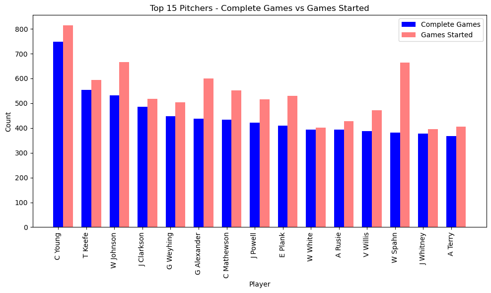

```python
import pandas as pd
import matplotlib.pyplot as plt

# Load the dataset
pitcher_stats = pd.read_csv("baseball_pitcher.csv")

# Filter the dataset to include only pitchers with at least 600 innings pitched
filtered_stats = pitcher_stats[pitcher_stats["Innings pitched"] >= 600]

# Select the top 15 rows based on "Complete games"
top_15 = filtered_stats.nlargest(15, "Complete Game")

# Create a grouped bar chart with player names and their Complete Games vs Games Started
plt.figure(figsize=(10, 6))

# Set the bar width
bar_width = 0.35

# Position of the bars on the x-axis
r1 = range(len(top_15))
r2 = [x + bar_width for x in r1]

# Plot Complete Games and Games Started using grouped bars
plt.bar(r1, top_15["Complete Game"], color='blue', width=bar_width, label='Complete Games')
plt.bar(r2, top_15["Games Started"], color='red', width=bar_width, alpha=0.5, label='Games Started')

# Set the x-axis ticks and labels
plt.xticks(range(len(top_15)), top_15["Player name"], rotation='vertical')

# Set the chart title and axis labels
plt.title("Top 15 Pitchers - Complete Games vs Games Started")
plt.xlabel("Player")
plt.ylabel("Count")

# Add legend
plt.legend()

# Add pitcher information separately
print("Pitcher Information:")
for _, row in top_15.iterrows():
    print("- Player: " + row["Player name"])
    print("  - Complete Games: " + str(row["Complete Game"]))
    print("  - Games Started: " + str(row["Games Started"]))
    print()

# Display the chart
plt.tight_layout()
plt.show()
```

We chose to use a grouped bar graph to represent this data because it effectively displays the information comparing the number of complete games pitchers have pitched compared to games started. We can easily see how many games each pitcher has started in pink, and how many complete games they have pitched in blue. This graph displays some of the most dominant and used pitchers of all time, as it shows us the pitchers with the most complete games pitched in the history of the MLB.